# Reproducible Research: Peer Assessment 1

# Load required Libraries

```r
library(ggplot2)
```

## Loading and preprocessing the data

```r
# Read activity.csv file
activity <- read.table("./activity/activity.csv", header=TRUE, sep=",",stringsAsFactors=FALSE)

## Explore
names(activity)
```

```
## [1] "steps"    "date"     "interval"
```

```r
head(activity)
```

```
##   steps       date interval
## 1    NA 2012-10-01        0
## 2    NA 2012-10-01        5
## 3    NA 2012-10-01       10
## 4    NA 2012-10-01       15
## 5    NA 2012-10-01       20
## 6    NA 2012-10-01       25
```

```r
## aggregate the steps on daily basis
DailyAggregatedSteps <- aggregate(steps ~ date, data = activity, sum, na.rm = TRUE)
```

## What is mean total number of steps taken per day?

1. Make a histogram of the total number of steps taken each day

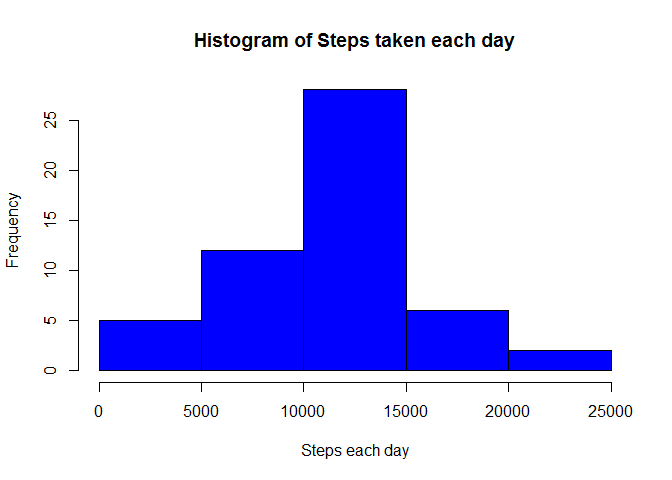

```r
hist(as.numeric(DailyAggregatedSteps$steps), col="blue", xlab="Steps each day",main="Histogram of Steps taken each day")
```

2. Calculate and report the **mean** and **median** total number of steps taken per day

```r
mean(as.numeric(DailyAggregatedSteps$steps))
```

```
## [1] 10766.19
```

```r
median(as.numeric(DailyAggregatedSteps$steps))
```

```
## [1] 10765
```

## What is the average daily activity pattern?

1. Make a time series plot (i.e. `type = "l"`) of the 5-minute interval (x-axis) and the average number of steps taken, averaged across all days (y-axis)

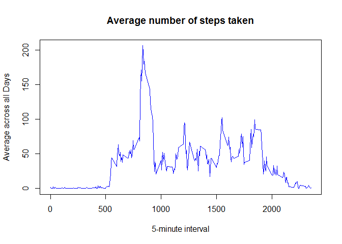

```r
# Get average across all days for each interval
interval_avg <- tapply(activity$steps, activity$interval, mean, na.rm = TRUE)

plot(row.names(interval_avg),
     interval_avg,
     type = "l",
     xlab = "5-minute interval",
     ylab = "Average across all Days", main = "Average number of steps taken",
     col = "blue")
```

2. Which 5-minute interval, on average across all the days in the dataset, contains the maximum number of steps?

```r
max_interval <- which.max(interval_avg)
names(max_interval)
```

```
## [1] "835"
```

## Imputing missing values

1. Calculate and report the total number of missing values in the dataset (i.e. the total number of rows with `NA`s)

```r
sum(is.na(activity$steps))
```

```
## [1] 2304
```

2. Devise a strategy for filling in all of the missing values in the dataset. The strategy does not need to be sophisticated. For example, you could use the mean/median for that day, or the mean for that 5-minute interval, etc.

```r
## Impute the missing step data factorwith interval average value from interval_avg
imputed_data <- transform(activity, steps=ifelse(is.na(steps), interval_avg, steps))
```

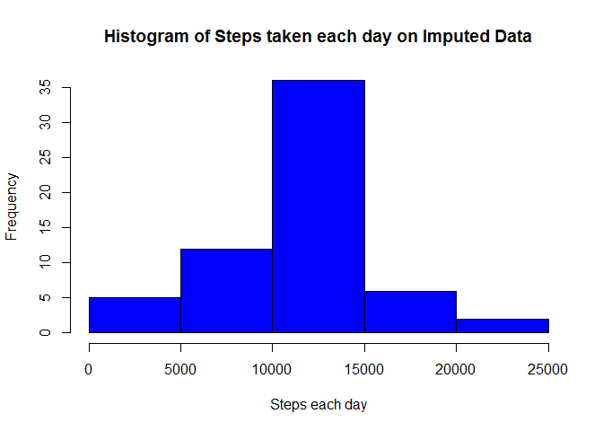

```r
## aggregate the steps on daily basis
DailyAggregatedSteps_imputed <- aggregate(steps ~ date, data = imputed_data, sum, na.rm = TRUE)

hist(as.numeric(DailyAggregatedSteps_imputed$steps), col="blue", xlab="Steps each day",main="Histogram of Steps taken each day on Imputed Data")
```

## Are there differences in activity patterns between weekdays and weekends?

1. Create a new factor variable in the dataset with two levels – “weekday” and “weekend” indicating whether a given date is a weekday or weekend day.

```r
week <- factor(weekdays(as.Date(imputed_data$date)) %in% c("Saturday","Sunday"),
               labels=c("weekday","weekend"), ordered=FALSE)

impute_steps <- aggregate(imputed_data$steps, by=list(interval=imputed_data$interval, weekday=week), mean)
```

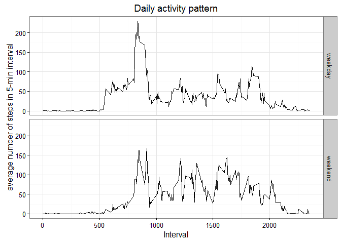

```r
g <- ggplot(impute_steps, aes(interval, x))
g + geom_line() + facet_grid(weekday ~ .) +
  labs(y="average number of steps in 5-min interval") +
  labs(x="Interval") +
  labs(title="Daily activity pattern")+
  theme_bw()
```